# Urban Social Disorder in major cities of the developing world

Programming Tools for Urban Analytics, Univeristy of Glasgow

25.03.2023

2749676J

```python
import pandas as pd
import numpy as np

import seaborn as sns
from matplotlib import pyplot as plt
from mpl_toolkits.basemap import Basemap
plt.rcParams.update({'font.size': 12})

from pmdarima.arima import auto_arima
from sklearn.preprocessing import StandardScaler
from sklearn.cluster import KMeans
from sklearn.mixture import GaussianMixture
from sklearn.metrics import silhouette_score
from sklearn.decomposition import PCA
from sklearn.manifold import TSNE
from sklearn.manifold import LocallyLinearEmbedding
```

## 1.Introduction

The phenomenon of political violence has been a major issue worldwide, and it has been a challenging task to predict, prevent, and mitigate its occurrence. The rapid demographic transition of the developing world from rural to urban areas has led to a transformation of political violence, with urban uprisings and terrorism replacing conventional and organized rural insurgencies. In this project, we will analyze a dataset that explores the occurrence and patterns of political violence in urban areas across the developing world over the past 55 years. This project aim to uncover trends, patterns, and risk factors associated with political violence in urban areas and explore the potential for predicting the likelihood of its occurrence. Specifically, the project plans to use time series analysis to learn the number of incidents per year in each country or region and to attempt to predict the number of social disorder incidents in these regions in the future.

In this project, we will be analyzing the Urban Social Disorder (USD) event dataset 2.0 from Kaggle that provides information on lethal and non-lethal disorder events in 103 cities across 89 countries in the developing world for the past 55 years (Urdal and Hoelscher, 2012). This dataset is gathered from electronic news articles present in Keesing's Record of World Events (KRWE).

The research questions are crystallised into these questions:

- What is the meaning of the observations and fields of this data and what type of data is it?
- Which fields will be useful for our research and which will interfere with the algorithm and therefore need to be removed?
- Which countries or regions have significantly different characteristics?
- What are the overall levels of social disorder in each region in this dataset and how do they differ from each other?
- What patterns can be found based on time series analysis? How effective are the forecasting models built from this data?
- How to determine the k-value for k-means clustering?
- How to interprete the "regions" generated using k-means clustering?
- What are the patterns and differences in the distribution of social disorder events in these cluster regions?

## 2.Data preprocessing

### 2.1 A glance at the data

```python
# create a pandas dataframe from the location data set
df = pd.read_csv("Urban_Social_Disorder-Kaggle/events.csv")
```

```python
# check the size of the dataframe
df.shape
```

```
(9018, 30)
```

```python
# check the head of the dataframe
df.head()
```

|  | EVENTID | CITY_ID | CITY | COUNTRY | ISO3 | GWNO | COUNTRY_HIST | GWNO_HIST | REGION | LONG | ... | ACTOR3 | TARGET1 | TARGET2 | NPART | NDEATH | ELOCAL | REPORTID1 | REPORTID2 | REPORTID3 | SUMMARY |
| --- | --- | --- | --- | --- | --- | --- | --- | --- | --- | --- | --- | --- | --- | --- | --- | --- | --- | --- | --- | --- | --- |
| 0 | 1-1 | 1 | Abidjan | Cote d'Ivoire | CIV | 437 | Cote d'Ivoire | 437.0 | Sub-Saharan Africa | -4.041994 | ... | NaN | Plot makers | NaN | 12 | 0 | 99 | 1-1A | NaN | NaN | A massive demonstration of support for Preside... |
| 1 | 1-2 | 1 | Abidjan | Cote d'Ivoire | CIV | 437 | Cote d'Ivoire | 437.0 | Sub-Saharan Africa | -4.041994 | ... | NaN | Government | NaN | 3 | 0 | University of Abidjan | 1-2A | NaN | NaN | On Jan. 23, 1967, the Parti democratique had d... |
| 2 | 1-3 | 1 | Abidjan | Cote d'Ivoire | CIV | 437 | Cote d'Ivoire | 437.0 | Sub-Saharan Africa | -4.041994 | ... | NaN | Government | NaN | 99 | 0 | University of Abidjan | 1-2B | NaN | NaN | The strike referred to by M. Yace had been cal... |
| 3 | 1-4 | 1 | Abidjan | Cote d'Ivoire | CIV | 437 | Cote d'Ivoire | 437.0 | Sub-Saharan Africa | -4.041994 | ... | NaN | Government | NaN | 11 | 0 | University of Abidjan | 1-3B | NaN | NaN | Following the arrest of some 100 students who ... |
| 4 | 1-5 | 1 | Abidjan | Cote d'Ivoire | CIV | 437 | Cote d'Ivoire | 437.0 | Sub-Saharan Africa | -4.041994 | ... | Doctors | Government | NaN | 12 | 0 | 99 | 1-3A | NaN | NaN | The country's longest strike, involving teache... |

5 rows × 30 columns

```python
# check the descriptive statistics of the dataframe
df.describe()
```

|  | CITY_ID | GWNO | GWNO_HIST | LONG | LAT | PTYPE | BDAY | BMONTH | BYEAR | EDAY | EMONTH | EYEAR | NPART |
| --- | --- | --- | --- | --- | --- | --- | --- | --- | --- | --- | --- | --- | --- |
| count | 9018.000000 | 9018.000000 | 8871.000000 | 9018.000000 | 9018.000000 | 9018.000000 | 9017.000000 | 9018.000000 | 9018.000000 | 9017.000000 | 9018.000000 | 9018.000000 | 9018.000000 |
| mean | 48.931470 | 537.754713 | 536.497125 | 27.369430 | 14.827322 | 44.744622 | 24.616724 | 6.866711 | 1990.619760 | 25.449041 | 6.958527 | 1990.625194 | 42.978709 |
| std | 28.138064 | 244.049818 | 245.936933 | 61.169852 | 22.128220 | 13.903918 | 27.409659 | 8.311434 | 15.323632 | 27.763481 | 8.666882 | 15.320672 | 45.293623 |
| min | 1.000000 | 40.000000 | 40.000000 | -99.132934 | -34.856096 | 10.000000 | 1.000000 | 1.000000 | 1960.000000 | 1.000000 | 1.000000 | 1960.000000 | 1.000000 |
| 25% | 24.000000 | 437.000000 | 433.000000 | -0.218662 | 2.068627 | 31.000000 | 9.000000 | 3.000000 | 1979.000000 | 9.000000 | 3.000000 | 1979.000000 | 4.000000 |
| 50% | 45.000000 | 640.000000 | 640.000000 | 35.931354 | 18.542970 | 42.000000 | 17.000000 | 6.000000 | 1991.000000 | 18.000000 | 6.000000 | 1991.000000 | 11.000000 |
| 75% | 74.000000 | 710.000000 | 713.000000 | 69.181314 | 33.830926 | 60.000000 | 26.000000 | 9.000000 | 2005.000000 | 26.000000 | 9.000000 | 2005.000000 | 99.000000 |
| max | 103.000000 | 850.000000 | 850.000000 | 139.749462 | 47.918619 | 62.000000 | 99.000000 | 99.000000 | 2014.000000 | 99.000000 | 99.000000 | 2014.000000 | 99.000000 |

```python
# check the data type
df.info()
```

```
<class 'pandas.core.frame.DataFrame'>
RangeIndex: 9018 entries, 0 to 9017
Data columns (total 30 columns):
 #   Column        Non-Null Count  Dtype
---  ------        --------------  -----
 0   EVENTID       9018 non-null   object
 1   CITY_ID       9018 non-null   int64
 2   CITY          9018 non-null   object
 3   COUNTRY       9018 non-null   object
 4   ISO3          9018 non-null   object
 5   GWNO          9018 non-null   int64
 6   COUNTRY_HIST  8871 non-null   object
 7   GWNO_HIST     8871 non-null   float64
 8   REGION        9018 non-null   object
 9   LONG          9018 non-null   float64
```

[output cut: 22 more lines]

As can be seen, the dataset contains 13 numerical out of 30 fields. Next let's look at the 13 numerical figures.

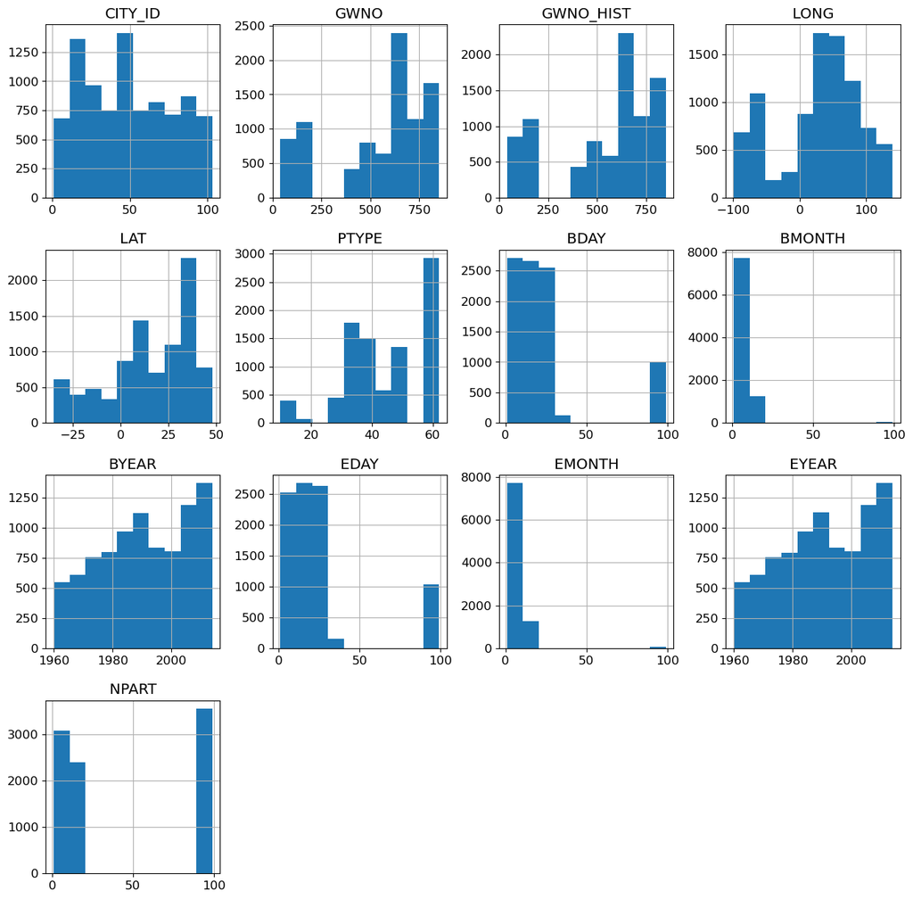

```python
import warnings
warnings.filterwarnings('ignore')

fig,ax = plt.subplots(figsize=(15,15))
df.hist(ax = ax)
plt.show()
```

### 2.2 Exploratory analysis

We perform a preliminary analysis of some variables of interest and those with missing values aiming to gain more insight into the data.

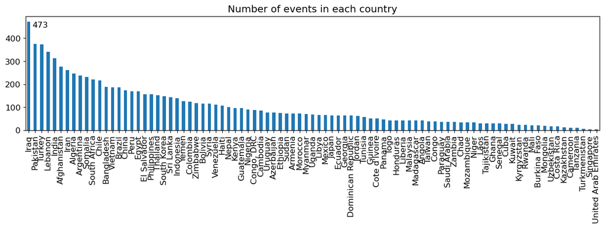

```python
# observe the distribution of number of events in each country

value_counts = df.COUNTRY.value_counts()
ax = value_counts.plot(kind='bar', figsize=(15,3), title= 'Number of events in each country')
ax.annotate(str(value_counts.iloc[0]), xy=(.5, value_counts.iloc[0]), ha='left', va='top')
plt.show()
```

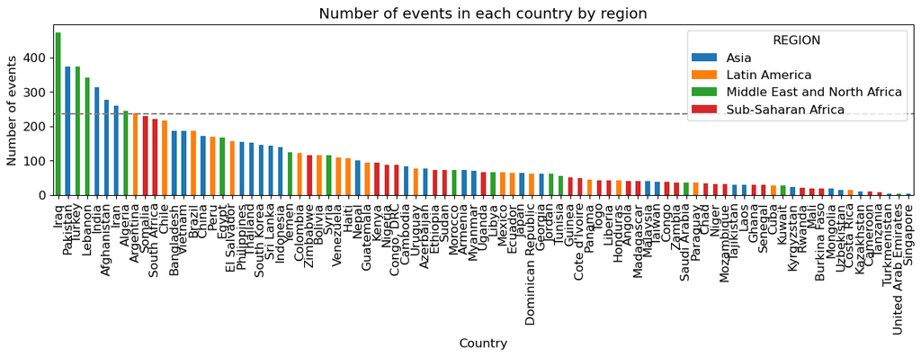

```python
# group the countries by REGION
(df.groupby('REGION')['COUNTRY'].value_counts()
       .unstack(level=0)
       .assign(SUM=lambda x: x.sum(axis=1))
       .sort_values(by='SUM', ascending=False)
       .drop('SUM', axis=1)
       .plot(kind='bar', figsize=(15,3), stacked=True)
       .set(title='Number of events in each country by region', xlabel='Country', ylabel='Number of events'))

# add a dotted line at the 50% of the max y value
plt.axhline(
    y=(np.max(np.nanmax(df.groupby('REGION')['COUNTRY'].value_counts().unstack(level=0).values, axis=1)))/2,
    color='grey',
    linestyle='--',
    zorder=2)

plt.show()
```

```python
# calculate number of missing
print(df.isnull().sum())
```

```
EVENTID            0
CITY_ID            0
CITY               0
COUNTRY            0
ISO3               0
GWNO               0
COUNTRY_HIST     147
GWNO_HIST        147
REGION             0
LONG               0
LAT                0
PTYPE              0
BDAY               1
BMONTH             0
BYEAR              0
EDAY               1
EMONTH             0
EYEAR              0
ACTOR1             0
ACTOR2          7467
ACTOR3          8734
TARGET1          265
TARGET2         8006
NPART              0
NDEATH             3
ELOCAL             0
REPORTID1          0
REPORTID2       8549
REPORTID3       8904
SUMMARY            0
dtype: int64
```

```python
# check the unique value of the data for ACTOR1
len(df.ACTOR1.unique())
```

```
2711
```

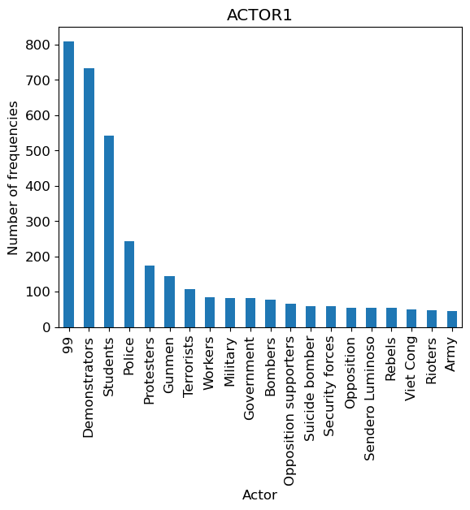

```python
# bar chart of data from ACTOR1
df.ACTOR1.value_counts().head(20).plot(kind="bar", rot=90)
plt.title("ACTOR1")
plt.xlabel("Actor")
plt.ylabel("Number of frequencies")
plt.show()
```

```python
# check the value_counts of target1 and target2
df[["TARGET1","TARGET2"]].value_counts()
```

```
TARGET1             TARGET2
Government          Police                        26
                    USA                           23
                    Civilians                     23
Police              Government                     8
Turkish government  Police                         6
                                                  ..
Government          Presidents                     1
                    Price increases                1
                    Prime Minister Hegazy          1
                    Prime Minister's residence     1
ZAPU                Liberation centre              1
Length: 812, dtype: int64
```

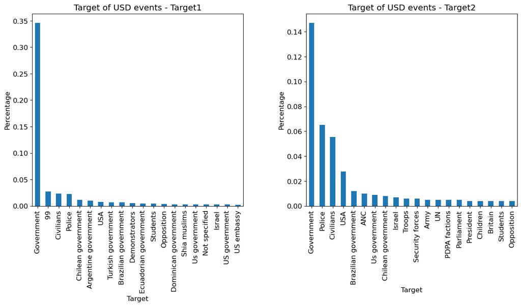

```python
# create fig
fig, axes = plt.subplots(1, 2, figsize=(15,6))

# Target1 plot
df.TARGET1.value_counts(normalize=True).head(20).plot(kind="bar", ax=axes[0], rot=90)
axes[0].set_title("Target of USD events - Target1")
axes[0].set_xlabel("Target")
axes[0].set_ylabel("Percentage")

# Target2 plot
df.TARGET2.value_counts(normalize=True).head(20).plot(kind="bar", ax=axes[1], rot=90)
axes[1].set_title("Target of USD events - Target2")
axes[1].set_xlabel("Target")
axes[1].set_ylabel("Percentage")

plt.subplots_adjust(wspace=0.3)
plt.show()
```

As can be seen from the two graphs above, **Government** was the most popular target for social disorder events, both as the first and second target, followed by Civilians and Police. it is reasonable to speculate that political and policy factors were significant contributors to social disorder events in these four regions during these decades. We draw this short conclusion for now, but to facilitate the subsequent time series analysis, we will remove the records with TARGET1 as null and remove the TARGET2 field.

### 2.3 Data Cleaning

In this section, we will check for duplicates and missing data and treat them accordingly to make the data easier to analyze.

```python
# calculate number of duplication
print(f"Number of duplicated records: {df.duplicated().sum()}")
```

```
Number of duplicated records: 0
```

```python
# calculate number of missing
print(df.isnull().sum())
```

```
EVENTID            0
CITY_ID            0
CITY               0
COUNTRY            0
ISO3               0
GWNO               0
COUNTRY_HIST     147
GWNO_HIST        147
REGION             0
LONG               0
LAT                0
PTYPE              0
BDAY               1
BMONTH             0
BYEAR              0
EDAY               1
EMONTH             0
EYEAR              0
ACTOR1             0
ACTOR2          7467
ACTOR3          8734
TARGET1          265
TARGET2         8006
NPART              0
NDEATH             3
ELOCAL             0
REPORTID1          0
REPORTID2       8549
REPORTID3       8904
SUMMARY            0
dtype: int64
```

```python
# 1. BDAY missing
# drop if BDAY is null
df = df.drop(df[df['BDAY'].isnull()].index)

# 99 also means missing but we will consider this later
```

```python
# 2. NDEATH
df.NDEATH.unique()
```

```
array(['0', '>1', '-99', '15', '35', '3', '10', '155', '30', '11', '1',
       '300', '19', '25', '>24', '50', '>0', '6', '8', '12', '4', '23',
       '5', '75', '21', '7', '27', '>5', '30-70', '26', '324', '3-9', '2',
       '       >200', '9', '300-500', '350', '       >100',
       '          >1', '         >11', '31', '         >26', '42',
       '          >4', '20', '96', '<21', '88', '<50', '>16', '74',
       '0-14', '22', '>18', '16', '>20', '13', '29', '34', '46-59', '267',
       '>103', '138', '17', '51', '>150', '>15', '17-20', '<50-70-150',
       '>6', '>9', '24', '<30', '>12', '>10', '<20', '200', '36', '18',
       '>33', '26-76', '400', '<10000', '59', '>200', '>2', '>11',
       '>20-30', '5-15', '28-100', '20-200', '5-50', '23-138', '>100',
       '25-50', '>17', '40-1000', '200-500', '>8', '90', '>300', '6-8',
       '8-10', '>62', '>131', '>2000', '>23', '>38', '<=9', '<=4', '>47',
       '>58', '>7', '>57', '>19', '>21', '<7', '<12', '40', '>37', '>22',
       '>32', '<16', '>26', '>14', '>4', '<27', '>29', '>13', '>27',
       '>30', '>25', '>43', '160', '33', '14', '43', '>56', '>87', '>71',
       '1400', '62', '>50', '>215', '>60', '>70', '>88', '>135', '>67',
       '>28', '189', '>35', '>75', '32', '<23', '<100', '99', '>3', '60',
       '<48', '28', '>40', '41', '>76', '<36', '>101', '>155', '>41',
       '>39', '70', '>45', '58', '44', '>36', '72', '<17', '<52', '<38',
       '65', '<22', '211', '>20-120', '<60', '<25', '<53', '>59', '38',
       '<75', '>34', '83-600', '92-170', '66', '100', '2000-5000', '<15',
       '2500', '100-400', '>1000', '17-53', '> 0', '> 700', '79', '105',
       '> 15', '80', '>130', '>52', '>63', '>84', '106', '107', '<9',
       '110', '4000-10000', '123', '>160', '>400-700', '>49', '8--15',
       '<1150', '87', '69', '23-29', '500-1000', '>42', '199', '>=2',
       '53', '78', '53-300', '2-8', '40-60', '>157', '1-6', '> 29', '55',
       '> 250', '1426', '39', '140', '230', '<6', '>74', '>79', '>61',
       '40-100', '49', '>1411', '>102', '>53', '18-400', '2--54',
       '500-1188 ', '>31', '22-80', '20-30', '220', '73-3000', '600',
       '3000', '500', '150', '30-50', '240', '1800', '1000', '250', '120',
       '112', '85', '>66', '>55', '20-100', '217', '67-367', '204-305',
       '47', '73', '80-200', '297', '193', '86', '52', '>139', '>80',
       '48', '35-150', '18-21', '700', '0-8', '130', '<870', '<35',
       '<200000', '<300000', '117', '17-30', '300-1000', '177',
       '       >101', '         >12', '4-9', '>600', '136', '100-1000',
       '207', '60-100', '>265', '22-50', '40-58', '37', '21-51', '116',
       '82-115', '6-64', '28-300', '4-28', '300-400', '4000', '54',
       '<200', '318', '          >1 ', '         >13', '          >6',
       '         >20', '          >2', '         >60', '         >15',
       '          >3', '        >12', '        >33', '         >93',
       '       >130', '         >39', '>267', '>81', '>113', '46', '>48',
       '>110', '16-15', '>600-1000', '>500', '<5000', '64', '>400',
       '200-300', '181', '170-195', '1-12', '          >7', '       >253',
       '67', '<5000-6000', '6--20', '2307-3874', '59-67', '3-14', '5-20',
       '10-77', '>550', '45', '208', nan, '50-200', '22-100', '40-70',
       '60-120', '100-120', '112-3000', '19--70', '100-200', '15-25',
       '>46', '5800', '>700', '<14', '2-7', '<28', '5-9', '<43',
       '<25-85-200', '187', '113', '16-63', '97-250', '45-58', '8-50',
       '180', '70-2000', '2-20'], dtype=object)
```

```python
# # This is a failed attempt

# # drop if NDEATH is null
# df = df.drop(df[df['NDEATH'].isnull()].index)

# # transform data range into number
# def convert_death_range(death_range):
#     if pd.isna(death_range):
#         return np.nan
#     elif death_range == -99:
#         return np.nan
#     elif '>' in death_range:
#         return int(death_range[1:])
#     elif '<' in death_range:
#         return int(death_range[1:])
#     elif '-' in death_range:
#         death_range = death_range.split('-')
#         return int(death_range[0]), int(death_range[1])
#     else:
#         return int(death_range)

# # clean NDEATH field
# # df['NDEATH'] = df['NDEATH'].apply(convert_death_range)
# df['NDEATH'].apply(convert_death_range)
```

```python
# drop NDEATH as its quality is too poor to use
df = df.drop('NDEATH', axis=1)
```

```python
# 3. ID data and text data

# dropping some of the ID data
df = df.drop(['EVENTID', 'COUNTRY_HIST', 'GWNO_HIST', 'ISO3', 'REPORTID1', 'REPORTID2', 'REPORTID3'], axis=1)

# Converting REGION to digital code
df["REGION_code"] = pd.Categorical(df["REGION"]).codes

# check the mapping
print(df[["REGION", "REGION_code"]].value_counts())

# drop text data
df = df.drop(['COUNTRY', 'CITY', 'REGION', 'ACTOR1', 'ACTOR2', 'ACTOR3', 'TARGET1', 'TARGET2', 'ELOCAL', 'SUMMARY'], axis=1)
```

```
REGION                        REGION_code
Asia                          0              3258
Middle East and North Africa  2              2165
Latin America                 1              1956
Sub-Saharan Africa            3              1638
dtype: int64
```

Now let's look at our data again.

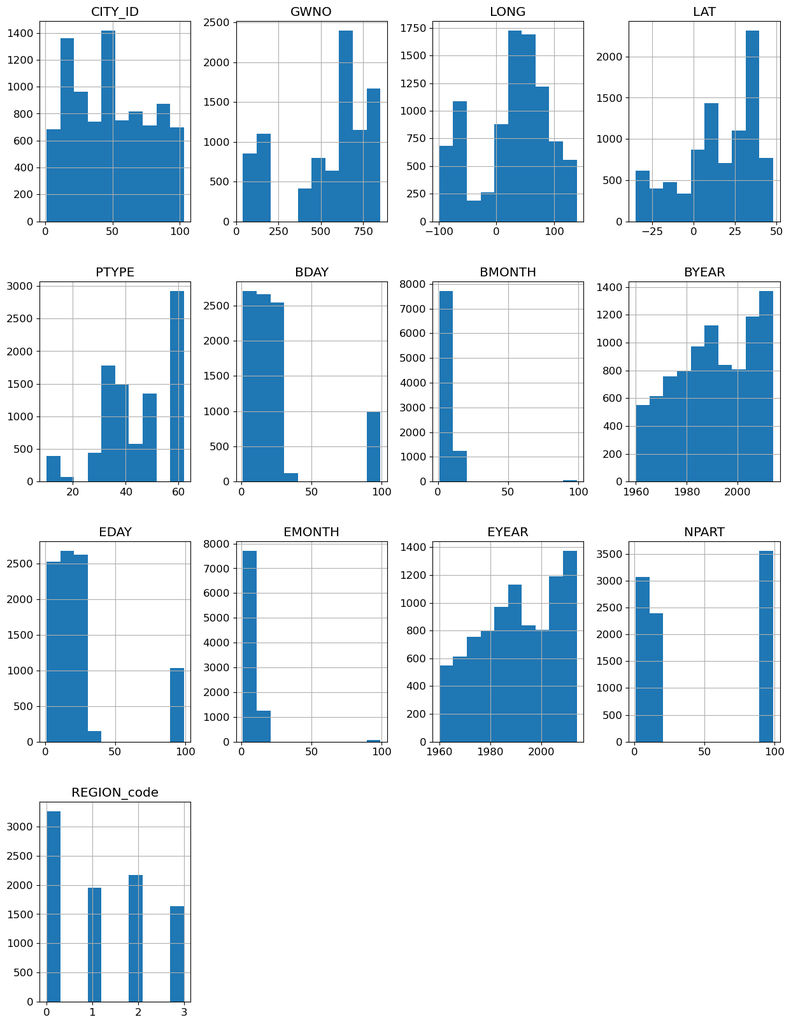

```python
warnings.filterwarnings('ignore')

fig,ax = plt.subplots(figsize=(15,20))
df.hist(ax = ax)
plt.show()
```

```python
print("Number of null(s) in the data:", df.isnull().sum().sum(), ".")
print("Number of observations:", df.shape[0])
print("Number of fields:", df.shape[1])
df.head()
```

```
Number of null(s) in the data: 0 .
Number of observations: 9017
Number of fields: 13
```

|  | CITY_ID | GWNO | LONG | LAT | PTYPE | BDAY | BMONTH | BYEAR | EDAY | EMONTH | EYEAR | NPART | REGION_code |
| --- | --- | --- | --- | --- | --- | --- | --- | --- | --- | --- | --- | --- | --- |
| 0 | 1 | 437 | -4.041994 | 5.321943 | 61 | 28.0 | 9 | 1963 | 28.0 | 9 | 1963 | 12 | 3 |
| 1 | 1 | 437 | -4.041994 | 5.321943 | 62 | 22.0 | 1 | 1967 | 22.0 | 1 | 1967 | 3 | 3 |
| 2 | 1 | 437 | -4.041994 | 5.321943 | 60 | 99.0 | 5 | 1967 | 26.0 | 5 | 1967 | 99 | 3 |
| 3 | 1 | 437 | -4.041994 | 5.321943 | 62 | 9.0 | 2 | 1981 | 9.0 | 2 | 1981 | 11 | 3 |
| 4 | 1 | 437 | -4.041994 | 5.321943 | 60 | 18.0 | 4 | 1983 | 3.0 | 5 | 1983 | 12 | 3 |

To see the spatial distribution of events, a map is created below with the coordinates of the city where the event took place.

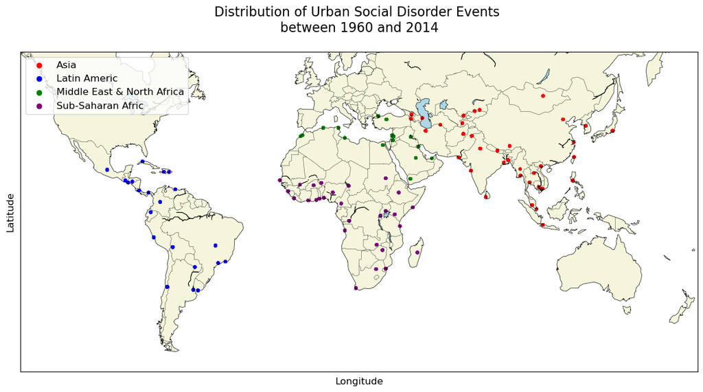

```python
# create figure object and set fig size
plt.figure(1, figsize=(15,8))

# set up basemap
m = Basemap(projection='merc', llcrnrlat=-60, urcrnrlat=60, llcrnrlon=-140, urcrnrlon=180, resolution='c')
# m.drawmapboundary(fill_color='#6495ED')
m.drawcoastlines(linewidth=0.5)
m.drawcountries(linewidth=0.3)
m.fillcontinents(color='beige', lake_color='lightblue')

# set colour mapping
color_dict = {0: "red", 1: "blue",2: "green", 3: "purple"}
region_dict = {0: "Asia", 1: "Latin Americ", 2: "Middle East & North Africa", 3: "Sub-Saharan Afric"}

# mapping scatter plot with colours based on the REGION_code field of the data
x, y = m(df['LONG'].values, df['LAT'].values)
plt.scatter(x, y, c=df['REGION_code'].map(color_dict), s=10)

# add legend
for region, color in color_dict.items():
    plt.scatter([], [], c=color, label=region_dict[region])
plt.legend(loc='upper left', fontsize=12)

# add labels and title
plt.xlabel("Longitude")
plt.ylabel("Latitude")
plt.title("Distribution of Urban Social Disorder Events \n between 1960 and 2014 \n", fontsize=16)

plt.show()
```

As can be seen, the events have been divided into four regions by the data collectors based on the geographical location in which they occurred. However, in some cases, using geographical location as a basis for classification may lead to some issues. For example, if a city belongs to a larger region based on its geographical location, but has significant differences from other cities in that region in other aspects, using the classification based on that larger region to analyze data from this city may mask its actual situation. In addition, since geographical location is a discrete classification, it may overlook the continuity and similarity between cities, which may be crucial for some problems. In such cases, using clustering methods can better reflect the similarities and differences between cities. In order to analyse the level of each event in each region, we will perform a cluster analysis of these cities later in this project.

### 2.4 Time series data preparation

Based on the above data pre-processing and visualisation, we found the potential of the dataset for analysing and predicting the spatial-temporal distribution patterns of social disorder events in these regions. Next, we will perform time series analysis and we wish to convert the start and end dates in this dataset into a start date timestamp.

```python
# coerce generate date
df['startDate'] = pd.to_datetime(df['BDAY'].round(1).astype(int).astype(str) +
                                 '-' + df['BMONTH'].astype(str) + '-' + df['BYEAR'].astype(str), errors='coerce')
# check illegal dates
print(df.isnull().sum())
```

```
CITY_ID          0
GWNO             0
LONG             0
LAT              0
PTYPE            0
BDAY             0
BMONTH           0
BYEAR            0
EDAY             0
EMONTH           0
EYEAR            0
NPART            0
REGION_code      0
startDate      994
dtype: int64
```

After coerce generating the timestamp, there is some illegitimate date data. We drop them.

```python
# drop if startDate is null
df = df.drop(df[df['startDate'].isnull()].index)

df.shape
```

```
(8023, 14)
```

So far, we have subtracted about 1000 records which is generally acceptable.

```python
# sort the data by time
df = df.sort_values(by='startDate')
df.head()

# startDate will be set as index if necessary.
```

|  | CITY_ID | GWNO | LONG | LAT | PTYPE | BDAY | BMONTH | BYEAR | EDAY | EMONTH | EYEAR | NPART | REGION_code | startDate |
| --- | --- | --- | --- | --- | --- | --- | --- | --- | --- | --- | --- | --- | --- | --- |
| 5980 | 64 | 520 | 45.364732 | 2.068627 | 51 | 1.0 | 7 | 1960 | 1.0 | 7 | 1960 | 99 | 3 | 1960-01-07 |
| 5079 | 51 | 490 | 15.313026 | -4.327778 | 51 | 1.0 | 7 | 1960 | 1.0 | 7 | 1960 | 99 | 3 | 1960-01-07 |
| 7054 | 78 | 600 | -6.833731 | 33.962679 | 60 | 1.0 | 11 | 1960 | 1.0 | 11 | 1960 | 12 | 2 | 1960-01-11 |
| 178 | 6 | 615 | 3.048607 | 36.765011 | 62 | 23.0 | 1 | 1960 | 23.0 | 1 | 1960 | 11 | 2 | 1960-01-23 |
| 179 | 6 | 615 | 3.048607 | 36.765011 | 51 | 24.0 | 1 | 1960 | 1.0 | 2 | 1960 | 12 | 2 | 1960-01-24 |

When analyzing time series data, different time granularities may provide varying degrees of detail and insight.(Khan and Singh, 2022) To determine the time granularity of time series analysis, a visualisation of the total number of events based on day, month and year is demenstrated below.

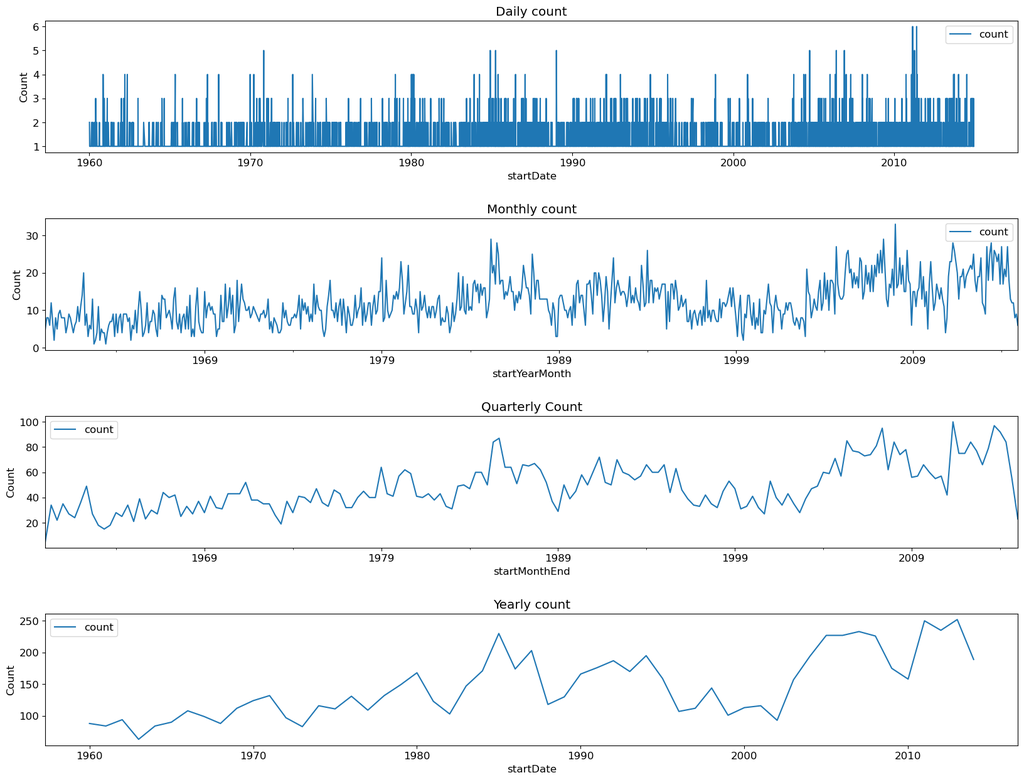

```python
fig, axes = plt.subplots(4, 1, figsize=(20,15))

daily_count = df.groupby(df['startDate'].dt.date).size().reset_index(name='count')
daily_count = daily_count.set_index('startDate')
daily_count.plot(kind="line", ax=axes[0])
axes[0].set_title("Daily count")
axes[0].set_ylabel("Count")

df['startYearMonth'] = df['startDate'].dt.to_period('M')  # monthly
monthly_count = df.groupby(df['startYearMonth']).size().reset_index(name='count')
monthly_count = monthly_count.set_index('startYearMonth')
monthly_count.plot(kind="line", ax=axes[1])
axes[1].set_title("Monthly count")
axes[1].set_ylabel("Count")

df['startMonthEnd'] = df['startDate'] + pd.offsets.MonthEnd(0)  # Transfer data into lastday of each month
monthly_count_end = df.groupby(df['startMonthEnd']).size().reset_index(name='count')
monthly_count_end = monthly_count_end.set_index('startMonthEnd')
quarterly_count = monthly_count_end.resample('4M').sum()  # Transfor data into quarterly count
quarterly_count.plot(kind='line', ax=axes[2])
axes[2].set_title('Quarterly Count')
axes[2].set_ylabel("Count")

yearly_count = df.groupby(df['startDate'].dt.year).size().reset_index(name='count')
yearly_count = yearly_count.set_index('startDate')
yearly_count.plot(kind="line", ax=axes[3])
axes[3].set_title("Yearly count")
axes[3].set_ylabel("Count")

plt.subplots_adjust(hspace=0.5)
plt.show()
```

## 3 Data analysis

### 3.1 An overview by region

In this section, we analyze the overall level of disorder by region, aiming to identify common and uncommon event types and explore regional variations. The expected outputs are an analysis revealing the relative frequency of event types and highlighting regional differences.

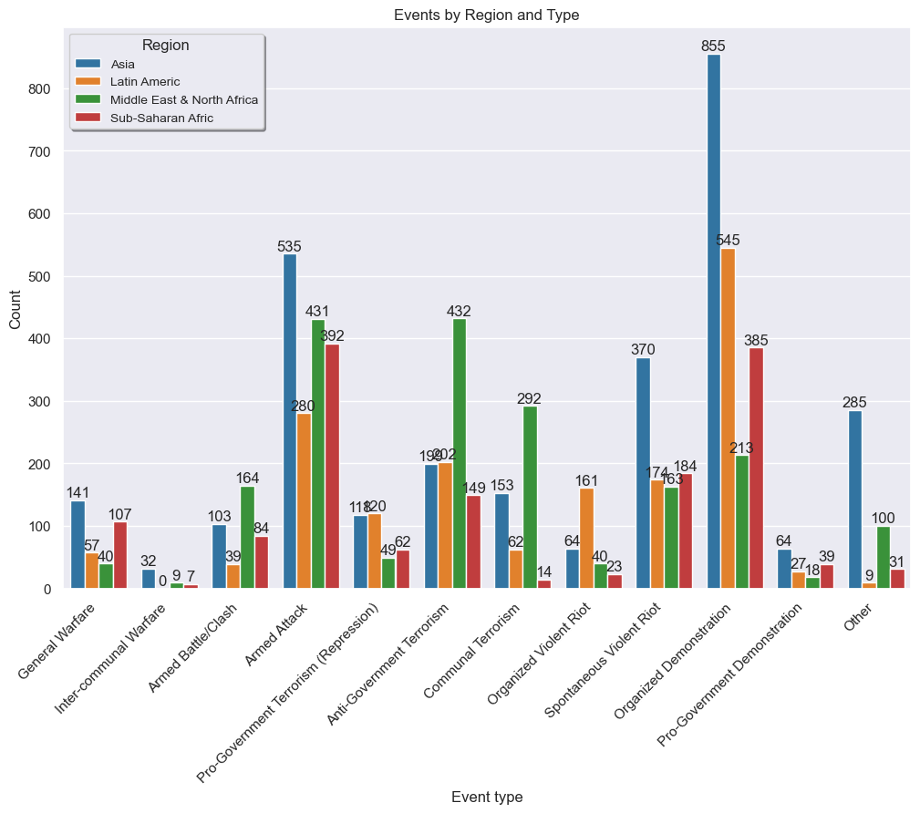

```python
# Set font scale and figure size
sns.set(font_scale=1)
plt.figure(figsize=(12,8))

# Define dictionary for region codes and event types
region_dict = {0: "Asia", 1: "Latin Americ", 2: "Middle East & North Africa", 3: "Sub-Saharan Afric"}
event_ticks = {1: 'General Warfare', 2: 'Inter-communal Warfare', 3: 'Armed Battle/Clash', 4: 'Armed Attack',
               5: 'Pro-Government Terrorism (Repression)', 6: 'Anti-Government Terrorism', 7: 'Communal Terrorism',
               8: 'Organized Violent Riot', 9: 'Spontaneous Violent Riot', 10: 'Organized Demonstration',
               11: 'Pro-Government Demonstration', 12: 'Other'}

# Create countplot
ax = sns.countplot(x='PTYPE', hue='REGION_code', data=df, palette='tab10')

# Set labels and title
plt.xlabel('Event type')
plt.xticks(range(12), [event_ticks[i] for i in range(1,13)], rotation=45, ha='right')
plt.ylabel('Count')
plt.title('Events by Region and Type')

# Set legend
handles, labels = ax.get_legend_handles_labels()
ax.legend(handles=handles, labels=[region_dict[int(label)] for label in labels], title='Region',
          title_fontsize='medium', fontsize='small', frameon=True, fancybox=True, shadow=True)

# Add annotations for count values
for p in ax.patches:
    ax.annotate(str(int(p.get_height())), (p.get_x() + p.get_width() / 2, p.get_height() + 5), ha='center')

# Show the plot
plt.show()
```

The countplot above illustrates considerable variations in the distribution of social disorder events across four regions.

Similarly, the Middle East & North Africa region reports a higher occurrence of Anti-Government Terrorism and Communal Terrorism, while Organized Demonstration and Pro-Government Demonstration events are notably less frequent than in other regions.

In contrast, Latin America demonstrates a higher frequency of Organized Violent Riot events, while Armed Battle/Clash incidents are less frequent compared to other regions.

In conclusion, the data graph reveals significant regional disparities in social disorder events, suggesting that contextual factors such as political instability, economic development, and cultural norms may shape the patterns of social disorder events worldwide.

### 3.2 Time series prediction

In this section, we use time series analysis to predict the number of social disorder events occurring in 4 regions. Auto-ARIMA was chosen for this project for the purpose of helping identifying the proper SARIMAX model.

### 3.2.1 Data Preprocessing

```python
# region_dict = {0: "Asia", 1: "Latin Americ", 2: "Middle East & North Africa", 3: "Sub-Saharan Afric"}

# Create univariate data for REGIONs for Auto-ARIMA
m0 = df[df.REGION_code == 0].groupby(df['startMonthEnd']).size().resample('4M').sum()
m1 = df[df.REGION_code == 1].groupby(df['startMonthEnd']).size().resample('4M').sum()
m2 = df[df.REGION_code == 2].groupby(df['startMonthEnd']).size().resample('4M').sum()
m3 = df[df.REGION_code == 3].groupby(df['startMonthEnd']).size().resample('4M').sum()
```

### 3.2.2 Model Building

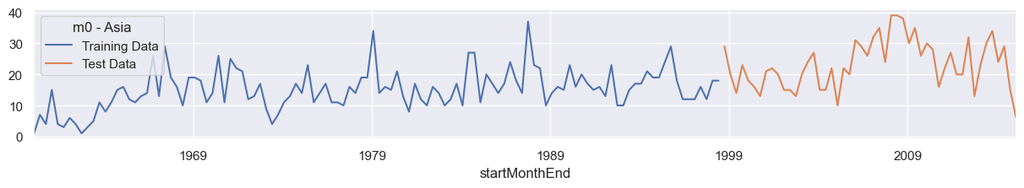

```python
# # Asia REGION
# Split the dataframe into training and testing sets with a ratio of 70:30
m0train = m0[:int(0.7*len(m0))]
m0test = m0[int(0.7*len(m0)):]

# Plotting the data
plt.figure(figsize=(15,2))
m0train.plot(label='Training Data')
m0test.plot(label='Test Data')
plt.legend(title='m0 - Asia')
plt.show()
```

```
Performing stepwise search to minimize aic
 ARIMA(2,1,2)(0,0,0)[0] intercept   : AIC=inf, Time=0.13 sec
 ARIMA(0,1,0)(0,0,0)[0] intercept   : AIC=781.482, Time=0.01 sec
 ARIMA(1,1,0)(0,0,0)[0] intercept   : AIC=754.308, Time=0.02 sec
 ARIMA(0,1,1)(0,0,0)[0] intercept   : AIC=738.375, Time=0.02 sec
 ARIMA(0,1,0)(0,0,0)[0]             : AIC=779.531, Time=0.01 sec
 ARIMA(1,1,1)(0,0,0)[0] intercept   : AIC=739.330, Time=0.03 sec
 ARIMA(0,1,2)(0,0,0)[0] intercept   : AIC=739.642, Time=0.03 sec
 ARIMA(1,1,2)(0,0,0)[0] intercept   : AIC=inf, Time=0.12 sec
 ARIMA(0,1,1)(0,0,0)[0]             : AIC=736.907, Time=0.01 sec
 ARIMA(1,1,1)(0,0,0)[0]             : AIC=738.151, Time=0.02 sec
 ARIMA(0,1,2)(0,0,0)[0]             : AIC=738.355, Time=0.02 sec
 ARIMA(1,1,0)(0,0,0)[0]             : AIC=752.418, Time=0.01 sec
 ARIMA(1,1,2)(0,0,0)[0]             : AIC=738.571, Time=0.04 sec

Best model:  ARIMA(0,1,1)(0,0,0)[0]
Total fit time: 0.459 seconds
```

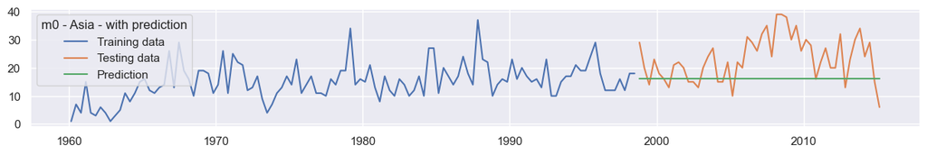

```python
# Build the model
model_auto0 = auto_arima(m0train, trace=True, error_action='ignore', supperss_warnings=True)
model_auto0.fit(m0train)

# Make forecast
forecast0 = model_auto0.predict(n_periods=len(m0test))
forecast0 = pd.DataFrame(forecast0, index=m0test.index, columns=['Prediction'])

# Plot the predictions for test dataset
plt.figure(figsize=(15,2))
plt.plot(m0train, label='Training data')
plt.plot(m0test, label='Testing data')
plt.plot(forecast0, label='Prediction')
# plt.plot([str(period) for period in m0train.index], m0train.values, label='Training data')
# plt.plot([str(period) for period in m0test.index], m0test.values, label='Testing data')
# plt.plot([str(period) for period in forecast0.index], forecast0.values, label='Prediction')
plt.legend(title='m0 - Asia - with prediction')
plt.show()
```

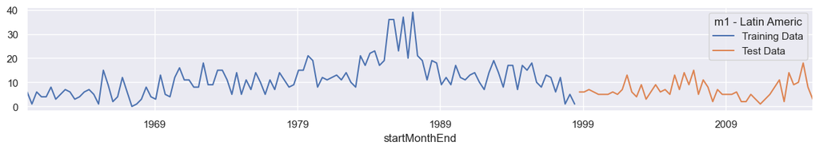

```python
# # Latin Americ REGION
# Split the dataframe into training and testing sets with a ratio of 70:30
m1train = m1[:int(0.7*len(m1))]
m1test = m1[int(0.7*len(m1)):]

# Plotting the data
plt.figure(figsize=(15,2))
m1train.plot(label='Training Data')
m1test.plot(label='Test Data')
plt.legend(title='m1 - Latin Americ')
plt.show()
```

```
Performing stepwise search to minimize aic
 ARIMA(2,1,2)(0,0,0)[0] intercept   : AIC=714.620, Time=0.05 sec
 ARIMA(0,1,0)(0,0,0)[0] intercept   : AIC=759.634, Time=0.01 sec
 ARIMA(1,1,0)(0,0,0)[0] intercept   : AIC=731.558, Time=0.02 sec
 ARIMA(0,1,1)(0,0,0)[0] intercept   : AIC=717.434, Time=0.02 sec
 ARIMA(0,1,0)(0,0,0)[0]             : AIC=757.639, Time=0.01 sec
 ARIMA(1,1,2)(0,0,0)[0] intercept   : AIC=716.354, Time=0.03 sec
 ARIMA(2,1,1)(0,0,0)[0] intercept   : AIC=719.365, Time=0.06 sec
 ARIMA(3,1,2)(0,0,0)[0] intercept   : AIC=714.027, Time=0.09 sec
 ARIMA(3,1,1)(0,0,0)[0] intercept   : AIC=718.043, Time=0.06 sec
 ARIMA(4,1,2)(0,0,0)[0] intercept   : AIC=inf, Time=0.18 sec
 ARIMA(3,1,3)(0,0,0)[0] intercept   : AIC=inf, Time=0.18 sec
 ARIMA(2,1,3)(0,0,0)[0] intercept   : AIC=inf, Time=0.16 sec
 ARIMA(4,1,1)(0,0,0)[0] intercept   : AIC=719.923, Time=0.07 sec
 ARIMA(4,1,3)(0,0,0)[0] intercept   : AIC=inf, Time=0.22 sec
 ARIMA(3,1,2)(0,0,0)[0]             : AIC=712.032, Time=0.06 sec
 ARIMA(2,1,2)(0,0,0)[0]             : AIC=712.629, Time=0.04 sec
 ARIMA(3,1,1)(0,0,0)[0]             : AIC=716.044, Time=0.03 sec
 ARIMA(4,1,2)(0,0,0)[0]             : AIC=inf, Time=0.16 sec
 ARIMA(3,1,3)(0,0,0)[0]             : AIC=inf, Time=0.16 sec
 ARIMA(2,1,1)(0,0,0)[0]             : AIC=717.367, Time=0.04 sec
 ARIMA(2,1,3)(0,0,0)[0]             : AIC=inf, Time=0.15 sec
 ARIMA(4,1,1)(0,0,0)[0]             : AIC=717.926, Time=0.05 sec
 ARIMA(4,1,3)(0,0,0)[0]             : AIC=inf, Time=0.18 sec

Best model:  ARIMA(3,1,2)(0,0,0)[0]
Total fit time: 2.043 seconds
```

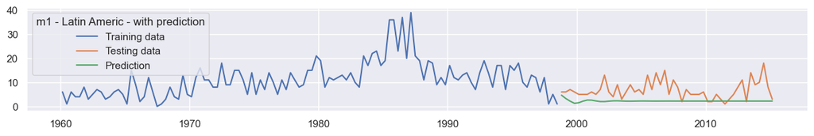

```python
# Building model
model_auto1 = auto_arima(m1train, trace=True, error_action='ignore', supperss_warnings=True)
model_auto1.fit(m1train)

# Make forecast
forecast1 = model_auto1.predict(n_periods=len(m1test))
forecast1 = pd.DataFrame(forecast1, index=m1test.index, columns=['Prediction'])

# Plot the predictions for test dataset
plt.figure(figsize=(15,2))
plt.plot(m1train, label='Training data')
plt.plot(m1test, label='Testing data')
plt.plot(forecast1, label='Prediction')
# plt.plot([str(period) for period in m1train.index], m1train.values, label='Training data')
# plt.plot([str(period) for period in m1test.index], m1test.values, label='Testing data')
# plt.plot([str(period) for period in forecast1.index], forecast1.values, label='Prediction')
plt.legend(title='m1 - Latin Americ - with prediction')
plt.show()
```

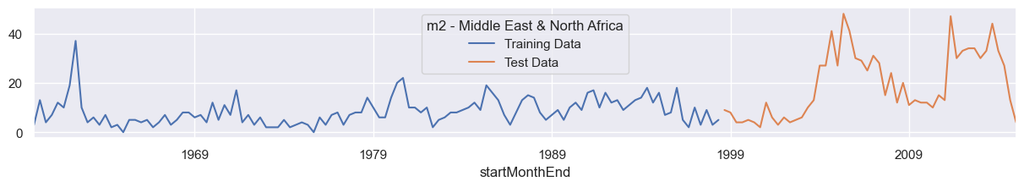

```python
# # Middle East & North Africa REGION
# Split the dataframe into training and testing sets with a ratio of 70:30
m2train = m2[:int(0.7*len(m2))]
m2test = m2[int(0.7*len(m2)):]

# Plotting the data
plt.figure(figsize=(15,2))
m2train.plot(label='Training Data')
m2test.plot(label='Test Data')
plt.legend(title='m2 - Middle East & North Africa')
plt.show()
```

```
Performing stepwise search to minimize aic
 ARIMA(2,0,2)(0,0,0)[0] intercept   : AIC=705.758, Time=0.04 sec
 ARIMA(0,0,0)(0,0,0)[0] intercept   : AIC=727.208, Time=0.01 sec
 ARIMA(1,0,0)(0,0,0)[0] intercept   : AIC=701.602, Time=0.02 sec
 ARIMA(0,0,1)(0,0,0)[0] intercept   : AIC=709.094, Time=0.03 sec
 ARIMA(0,0,0)(0,0,0)[0]             : AIC=866.320, Time=0.01 sec
 ARIMA(2,0,0)(0,0,0)[0] intercept   : AIC=701.911, Time=0.03 sec
 ARIMA(1,0,1)(0,0,0)[0] intercept   : AIC=701.763, Time=0.03 sec
 ARIMA(2,0,1)(0,0,0)[0] intercept   : AIC=703.755, Time=0.06 sec
 ARIMA(1,0,0)(0,0,0)[0]             : AIC=726.826, Time=0.01 sec

Best model:  ARIMA(1,0,0)(0,0,0)[0] intercept
Total fit time: 0.225 seconds
```

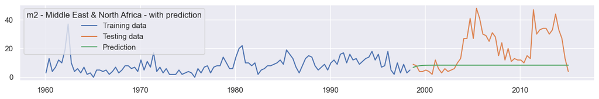

```python
# Building model
model_auto2 = auto_arima(m2train, trace=True, error_action='ignore', supperss_warnings=True)
model_auto2.fit(m2train)

# Make forecast
forecast2 = model_auto2.predict(n_periods=len(m2test))
forecast2 = pd.DataFrame(forecast2, index=m2test.index, columns=['Prediction'])

# Plot the predictions for test dataset
plt.figure(figsize=(15,2))
plt.plot(m2train, label='Training data')
plt.plot(m2test, label='Testing data')
plt.plot(forecast2, label='Prediction')
# plt.plot([str(period) for period in m2train.index], m2train.values, label='Training data')
# plt.plot([str(period) for period in m2test.index], m2test.values, label='Testing data')
# plt.plot([str(period) for period in forecast2.index], forecast2.values, label='Prediction')
plt.legend(title='m2 - Middle East & North Africa - with prediction')
plt.show()
```

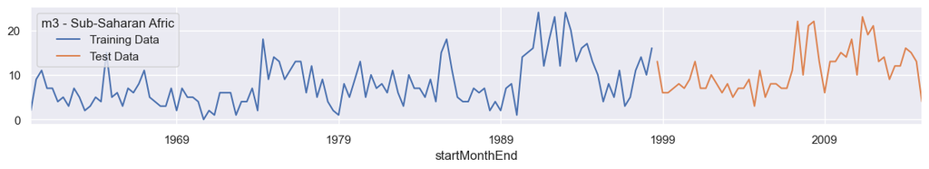

```python
# # Sub-Saharan Afric REGION
# Split the dataframe into training and testing sets with a ratio of 70:30
m3train = m3[:int(0.7*len(m3))]
m3test = m3[int(0.7*len(m3)):]

# Pplotting the data
plt.figure(figsize=(15,2))
m3train.plot(label='Training Data')
m3test.plot(label='Test Data')
plt.legend(title='m3 - Sub-Saharan Afric')
plt.show()
```

```
Performing stepwise search to minimize aic
 ARIMA(2,1,2)(0,0,0)[0] intercept   : AIC=inf, Time=0.14 sec
 ARIMA(0,1,0)(0,0,0)[0] intercept   : AIC=702.482, Time=0.01 sec
 ARIMA(1,1,0)(0,0,0)[0] intercept   : AIC=672.531, Time=0.02 sec
 ARIMA(0,1,1)(0,0,0)[0] intercept   : AIC=668.313, Time=0.02 sec
 ARIMA(0,1,0)(0,0,0)[0]             : AIC=700.549, Time=0.01 sec
 ARIMA(1,1,1)(0,0,0)[0] intercept   : AIC=669.273, Time=0.02 sec
 ARIMA(0,1,2)(0,0,0)[0] intercept   : AIC=669.469, Time=0.03 sec
 ARIMA(1,1,2)(0,0,0)[0] intercept   : AIC=671.258, Time=0.05 sec
 ARIMA(0,1,1)(0,0,0)[0]             : AIC=666.442, Time=0.01 sec
 ARIMA(1,1,1)(0,0,0)[0]             : AIC=667.394, Time=0.01 sec
 ARIMA(0,1,2)(0,0,0)[0]             : AIC=667.590, Time=0.02 sec
 ARIMA(1,1,0)(0,0,0)[0]             : AIC=670.626, Time=0.01 sec
 ARIMA(1,1,2)(0,0,0)[0]             : AIC=669.379, Time=0.02 sec

Best model:  ARIMA(0,1,1)(0,0,0)[0]
Total fit time: 0.362 seconds
```

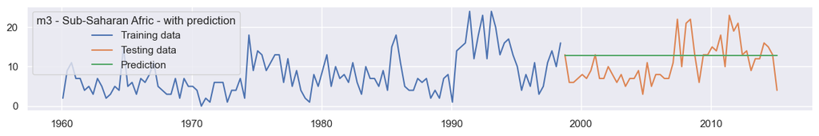

```python
# Building model
model_auto3 = auto_arima(m3train, trace=True, error_action='ignore', supperss_warnings=True)
model_auto3.fit(m3train)

# Make forecast
forecast3 = model_auto3.predict(n_periods=len(m3test))
forecast3 = pd.DataFrame(forecast3, index=m3test.index, columns=['Prediction'])

# Plot the predictions for test dataset
plt.figure(figsize=(15,2))
plt.plot(m3train, label='Training data')
plt.plot(m3test, label='Testing data')
plt.plot(forecast3, label='Prediction')
# plt.plot([str(period) for period in m3train.index], m3train.values, label='Training data')
# plt.plot([str(period) for period in m3test.index], m3test.values, label='Testing data')
# plt.plot([str(period) for period in forecast3.index], forecast3.values, label='Prediction')
plt.legend(title='m3 - Sub-Saharan Afric - with prediction')
plt.show()
```

### 3.2.3 Model evaluation

```python
# m0 - Asian
model_auto0.summary()
```

SARIMAX Results

| Dep. Variable: | y | No. Observations: | 116 |
| --- | --- | --- | --- |
| Model: | SARIMAX(0, 1, 1) | Log Likelihood | -366.454 |
| Date: | Mon, 03 Apr 2023 | AIC | 736.907 |
| Time: | 21:44:25 | BIC | 742.397 |
| Sample: | 02-29-1960 | HQIC | 739.135 |
|  | - 06-30-1998 |  |  |
| Covariance Type: | opg |  |  |

|  | coef | std err | z | P>\|z\| | [0.025 | 0.975] |
| --- | --- | --- | --- | --- | --- | --- |
| ma.L1 | -0.7469 | 0.068 | -11.001 | 0.000 | -0.880 | -0.614 |
| sigma2 | 34.0602 | 3.739 | 9.108 | 0.000 | 26.731 | 41.389 |

| Ljung-Box (L1) (Q): | 0.25 | Jarque-Bera (JB): | 12.67 |
| --- | --- | --- | --- |
| Prob(Q): | 0.62 | Prob(JB): | 0.00 |
| Heteroskedasticity (H): | 1.03 | Skew: | 0.70 |
| Prob(H) (two-sided): | 0.94 | Kurtosis: | 3.82 |

Warnings:  
[1] Covariance matrix calculated using the outer product of gradients (complex-step).

```python
# m1 - Latin Americ
model_auto1.summary()
```

SARIMAX Results

| Dep. Variable: | y | No. Observations: | 116 |
| --- | --- | --- | --- |
| Model: | SARIMAX(3, 1, 2) | Log Likelihood | -350.016 |
| Date: | Mon, 03 Apr 2023 | AIC | 712.032 |
| Time: | 21:44:26 | BIC | 728.502 |
| Sample: | 02-29-1960 | HQIC | 718.717 |
|  | - 06-30-1998 |  |  |
| Covariance Type: | opg |  |  |

|  | coef | std err | z | P>\|z\| | [0.025 | 0.975] |
| --- | --- | --- | --- | --- | --- | --- |
| ar.L1 | 0.5156 | 0.119 | 4.347 | 0.000 | 0.283 | 0.748 |
| ar.L2 | -0.3489 | 0.086 | -4.076 | 0.000 | -0.517 | -0.181 |
| ar.L3 | -0.2158 | 0.081 | -2.667 | 0.008 | -0.374 | -0.057 |
| ma.L1 | -1.2666 | 0.088 | -14.371 | 0.000 | -1.439 | -1.094 |
| ma.L2 | 0.8471 | 0.076 | 11.192 | 0.000 | 0.699 | 0.995 |
| sigma2 | 25.4371 | 3.794 | 6.705 | 0.000 | 18.002 | 32.872 |

| Ljung-Box (L1) (Q): | 0.02 | Jarque-Bera (JB): | 0.45 |
| --- | --- | --- | --- |
| Prob(Q): | 0.89 | Prob(JB): | 0.80 |
| Heteroskedasticity (H): | 2.00 | Skew: | -0.13 |
| Prob(H) (two-sided): | 0.04 | Kurtosis: | 2.84 |

Warnings:  
[1] Covariance matrix calculated using the outer product of gradients (complex-step).

```python
# m2 - Middle East & North Africa
model_auto2.summary()
```

SARIMAX Results

| Dep. Variable: | y | No. Observations: | 116 |
| --- | --- | --- | --- |
| Model: | SARIMAX(1, 0, 0) | Log Likelihood | -347.801 |
| Date: | Mon, 03 Apr 2023 | AIC | 701.602 |
| Time: | 21:44:26 | BIC | 709.863 |
| Sample: | 01-31-1960 | HQIC | 704.955 |
|  | - 05-31-1998 |  |  |
| Covariance Type: | opg |  |  |

|  | coef | std err | z | P>\|z\| | [0.025 | 0.975] |
| --- | --- | --- | --- | --- | --- | --- |
| intercept | 4.5068 | 0.879 | 5.127 | 0.000 | 2.784 | 6.230 |
| ar.L1 | 0.4608 | 0.059 | 7.861 | 0.000 | 0.346 | 0.576 |
| sigma2 | 23.4911 | 2.095 | 11.212 | 0.000 | 19.385 | 27.597 |

| Ljung-Box (L1) (Q): | 0.38 | Jarque-Bera (JB): | 92.31 |
| --- | --- | --- | --- |
| Prob(Q): | 0.54 | Prob(JB): | 0.00 |
| Heteroskedasticity (H): | 0.51 | Skew: | 1.14 |
| Prob(H) (two-sided): | 0.04 | Kurtosis: | 6.72 |

Warnings:  
[1] Covariance matrix calculated using the outer product of gradients (complex-step).

```python
# m3 - Sub-Saharan Afric
model_auto3.summary()
```

SARIMAX Results

| Dep. Variable: | y | No. Observations: | 116 |
| --- | --- | --- | --- |
| Model: | SARIMAX(0, 1, 1) | Log Likelihood | -331.221 |
| Date: | Mon, 03 Apr 2023 | AIC | 666.442 |
| Time: | 21:44:26 | BIC | 671.931 |
| Sample: | 01-31-1960 | HQIC | 668.670 |
|  | - 05-31-1998 |  |  |
| Covariance Type: | opg |  |  |

|  | coef | std err | z | P>\|z\| | [0.025 | 0.975] |
| --- | --- | --- | --- | --- | --- | --- |
| ma.L1 | -0.5720 | 0.071 | -8.062 | 0.000 | -0.711 | -0.433 |
| sigma2 | 18.5235 | 2.246 | 8.247 | 0.000 | 14.121 | 22.925 |

| Ljung-Box (L1) (Q): | 0.19 | Jarque-Bera (JB): | 7.06 |
| --- | --- | --- | --- |
| Prob(Q): | 0.66 | Prob(JB): | 0.03 |
| Heteroskedasticity (H): | 2.42 | Skew: | 0.59 |
| Prob(H) (two-sided): | 0.01 | Kurtosis: | 3.29 |

Warnings:  
[1] Covariance matrix calculated using the outer product of gradients (complex-step).

The model for Asia region (SARIMAX(0,1,1)) demonstrated a good fit to the data, with a significant coefficient for the moving average term and no evidence of serial correlation based on the Ljung-Box test. The residuals, however, may not be normally distributed according to the JB test.

Overall, each model demonstrated strengths and limitations, with some models having better fit statistics but potential issues with the distribution of residuals.

## 3.3 Clustering

We will examine social disorder by event. In this section, instead of using the REGION classification of the original data, we cluster the different cities according to their attributes in an attempt to break the limitations of classifying based on only spatial distribution. The results of clustering and further analysis are then explored and interpreted.

### 3.3.1 Data Preprocessing

We chose the unsupervised machine learning algorithm k-means clustering as an attempt to find the main patterns and structures in the dataset. The aim is to find the clusters of cities in this dataset. We start by extracting the cites and their attributes from df.

```python
df.info()
```

```
<class 'pandas.core.frame.DataFrame'>
Int64Index: 8023 entries, 5980 to 2356
Data columns (total 16 columns):
 #   Column          Non-Null Count  Dtype
---  ------          --------------  -----
 0   CITY_ID         8023 non-null   int64
 1   GWNO            8023 non-null   int64
 2   LONG            8023 non-null   float64
 3   LAT             8023 non-null   float64
 4   PTYPE           8023 non-null   int64
 5   BDAY            8023 non-null   float64
 6   BMONTH          8023 non-null   int64
 7   BYEAR           8023 non-null   int64
 8   EDAY            8023 non-null   float64
 9   EMONTH          8023 non-null   int64
 10  EYEAR           8023 non-null   int64
 11  NPART           8023 non-null   int64
 12  REGION_code     8023 non-null   int8
 13  startDate       8023 non-null   datetime64[ns]
 14  startYearMonth  8023 non-null   period[M]
 15  startMonthEnd   8023 non-null   datetime64[ns]
dtypes: datetime64[ns](2), float64(4), int64(8), int8(1), period[M](1)
memory usage: 1.2 MB
```

```python
# What we need are every city-related attributes in the dataset, including
#     CITY_ID, the number of various types of events occurring in each city, and LONG, LAT, GWNO, REGION_code

# Create dummy variables
dummy_df = pd.get_dummies(df['PTYPE'], prefix='PTYPE')

# Merge the dummy variable and CITY_ID into a new data box
merged_df = pd.concat([df[['CITY_ID']], dummy_df], axis=1)

# Grouping by CITY_ID and counting the number of individual NPART categories
result_df = merged_df.groupby('CITY_ID').sum()

# Mapping LONG, LAT, GWNO, REGION_code fields to result_df based on CITY_ID
result_df = result_df.merge(df[['CITY_ID', 'LONG', 'LAT', 'GWNO', 'REGION_code']].drop_duplicates(), on='CITY_ID')

# Set CITY_ID to index
result_df.set_index('CITY_ID', inplace=True)

# Result
result_df.head()
```

| CITY_ID | PTYPE_10 | PTYPE_20 | PTYPE_30 | PTYPE_31 | PTYPE_40 | PTYPE_41 | PTYPE_42 | PTYPE_50 | PTYPE_51 | PTYPE_60 | PTYPE_61 | PTYPE_62 | LONG | LAT | GWNO | REGION_code |
| --- | --- | --- | --- | --- | --- | --- | --- | --- | --- | --- | --- | --- | --- | --- | --- | --- |
| 1 | 0 | 0 | 1 | 9 | 2 | 1 | 1 | 1 | 9 | 4 | 6 | 6 | -4.041994 | 5.321943 | 437 | 3 |
| 2 | 0 | 0 | 0 | 1 | 0 | 2 | 0 | 0 | 0 | 0 | 0 | 0 | 54.366593 | 24.466684 | 696 | 2 |
| 3 | 0 | 0 | 0 | 1 | 1 | 7 | 0 | 0 | 2 | 6 | 1 | 1 | 7.531382 | 9.085279 | 475 | 3 |
| 4 | 0 | 0 | 0 | 8 | 0 | 6 | 0 | 0 | 0 | 7 | 6 | 0 | -0.218662 | 5.551980 | 452 | 3 |
| 5 | 0 | 0 | 0 | 27 | 3 | 9 | 0 | 0 | 1 | 28 | 2 | 0 | 38.698059 | 9.035256 | 530 | 3 |

### 3.3.2 Identify the optimal k-value

In this secsion, 4 predominant approaches were used to determine k values.

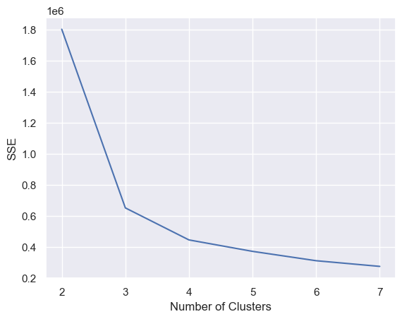

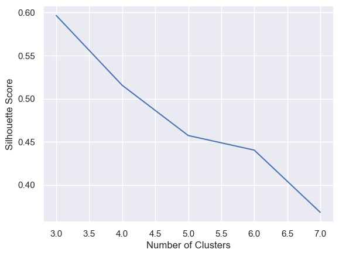

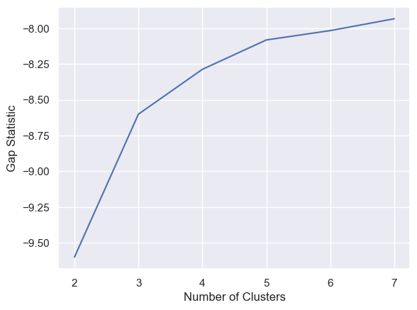

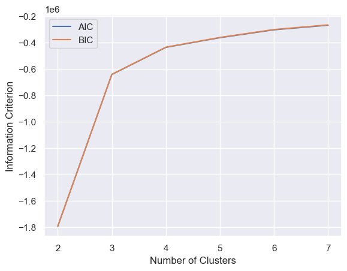

```python
# Initialize lists of results
sse = []
silhouette_scores = []
gap_statistics = []
aic = []
bic = []

# Extract feature matrix
X = result_df.values

# Loop to try different k
for k in range(2, 8):
    # KMeans clustering
    kmeans = KMeans(n_clusters=k, random_state=0)
    kmeans.fit(X)

    # Calculate SSE
    sse.append(kmeans.inertia_)

    # Calculate sihouette score
    if k > 2:
        silhouette_scores.append(silhouette_score(X, kmeans.labels_))

    # Calculate Gap statistics
    reference = np.random.rand(*X.shape)
    reference_inertia = KMeans(n_clusters=k, random_state=42).fit(reference).inertia_
    gap_statistics.append(np.log(reference_inertia) - np.log(kmeans.inertia_))

    # Cluster with GMM algorithm, and calculate AIC and BIC
    gmm = GaussianMixture(n_components=k, random_state=42)
    gmm.fit(X)
    kmeans_inertia = kmeans.inertia_
    aic.append(gmm.aic(X) - kmeans_inertia)
    bic.append(gmm.bic(X) - kmeans_inertia)

# Plot relationship between SSE and k
plt.plot(range(2, 8), sse, label='SSE')
plt.xlabel('Number of Clusters')
plt.ylabel('SSE')
plt.show()

# Plot relationship between Sihouette Score and k
plt.plot(range(3, 8), silhouette_scores, label='Sihouette Score')
plt.xlabel('Number of Clusters')
plt.ylabel('Silhouette Score')
plt.show()

# Plot relationship between Gap statistics and k
plt.plot(range(2, 8), gap_statistics, label='Gap Statistics')
plt.xlabel('Number of Clusters')
plt.ylabel('Gap Statistic')
plt.show()

# Plot relationship between AIC/BIC and k
plt.plot(range(2, 8), aic, label='AIC')
plt.plot(range(2, 8), bic, label='BIC')
plt.xlabel('Number of Clusters')
plt.ylabel('Information Criterion')
plt.legend()
plt.show()
```

The range of values for k is set to 2 to 8. The point at which the slope of the SSE plot changes significantly is k = 3, when the silhouette score reached maximum. Besides, although the Gap statistic and the AIC and BIC do not reach a maximum at k = 3, they have a dramatic change in slope and the curve is convex upwards. Based on these results, a reasonable choice for the number of clusters could be 3.

### 3.3.3 Clustering and visualization

```python
# k
k = 3

# Initialize KMeans model
kmeans = KMeans(n_clusters=k, random_state=0)

# Clustering df
kmeans.fit(result_df)

# Get cluster of each sample
cluster_labels = kmeans.labels_

# Get center of each cluster
cluster_centers = kmeans.cluster_centers_

print('Number of clusters:', len(np.unique(cluster_labels)))
print('Dimensions of data:', len(cluster_centers[0]))
```

```
Number of clusters: 3
Dimensions of data: 16
```

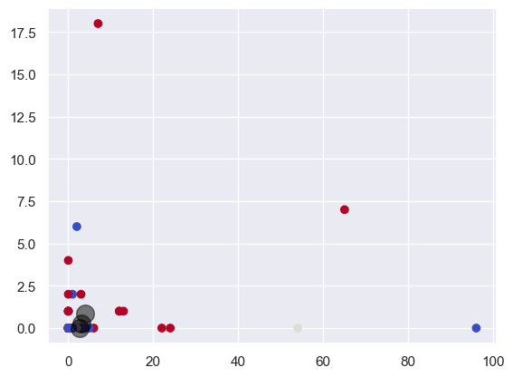

```python
# Visualize the centers of the clusters
plt.scatter(X[:, 0], X[:, 1], c=cluster_labels, cmap='coolwarm')
plt.scatter(cluster_centers[:, 0], cluster_centers[:, 1], c='black', s=200, alpha=0.5)
plt.show()
```

All the centres almost resting together, while the data are almost all scattered in irregular rows. This may be because more data features or more complex models are needed to better understand and cluster this data. Therefore, we try to look further at this clustering through some types of downscaling visualisation.

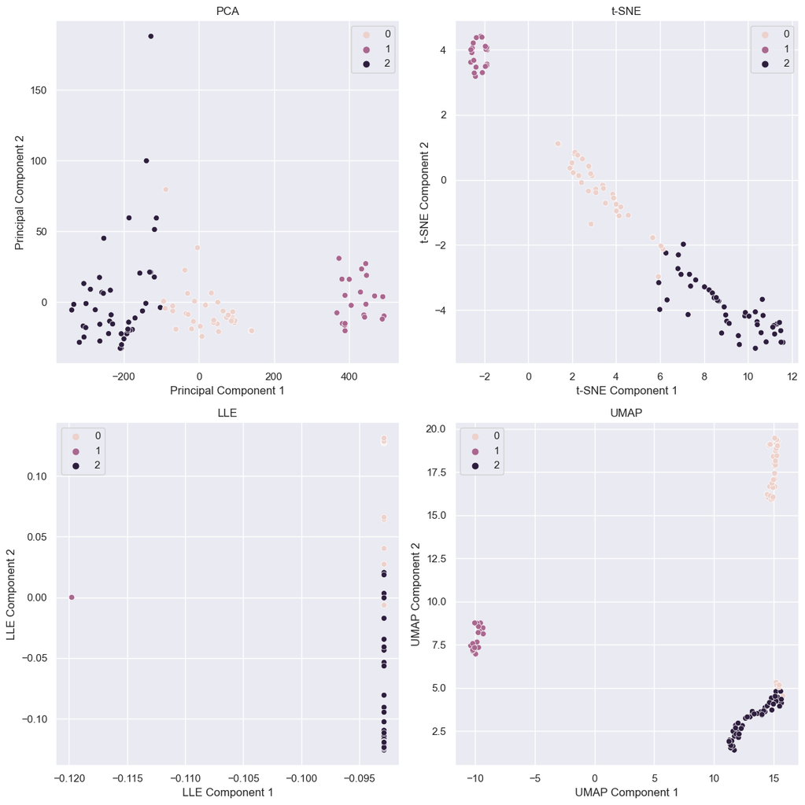

```python
# Create figure object
fig, axs = plt.subplots(2, 2, figsize=(12, 12))

# PCA (Principal Component Analysis)
pca = PCA(n_components=2)
X_pca = pca.fit_transform(X)
sns.scatterplot(x=X_pca[:, 0], y=X_pca[:, 1], hue=cluster_labels, ax=axs[0, 0])
axs[0, 0].set_title('PCA')
axs[0, 0].set_xlabel('Principal Component 1')
axs[0, 0].set_ylabel('Principal Component 2')

# t-SNE (t-Distributed Stochastic Neighbor Embeddin)
tsne = TSNE(n_components=2)
X_tsne = tsne.fit_transform(X)
sns.scatterplot(x=X_tsne[:, 0], y=X_tsne[:, 1], hue=cluster_labels, ax=axs[0, 1])
axs[0, 1].set_title('t-SNE')
axs[0, 1].set_xlabel('t-SNE Component 1')
axs[0, 1].set_ylabel('t-SNE Component 2')

# LLE (Locally Linear Embedding)
lle = LocallyLinearEmbedding(n_components=2, random_state=0)
X_lle = lle.fit_transform(X)
sns.scatterplot(x=X_lle[:, 0], y=X_lle[:, 1], hue=cluster_labels, ax=axs[1, 0])
axs[1, 0].set_title('LLE')
axs[1, 0].set_xlabel('LLE Component 1')
axs[1, 0].set_ylabel('LLE Component 2')

# UMAP（Uniform Manifold Approximation and Projection）
import umap.umap_ as umap
umap = umap.UMAP(n_components=2, random_state=0)
X_umap = umap.fit_transform(X)
sns.scatterplot(x=X_umap[:, 0], y=X_umap[:, 1], hue=cluster_labels, ax=axs[1, 1])
axs[1, 1].set_title('UMAP')
axs[1, 1].set_xlabel('UMAP Component 1')
axs[1, 1].set_ylabel('UMAP Component 2')

# auto adjust spacing and margins
plt.tight_layout()
plt.show()
```

As can be seen, The clusters have tightly clustered data points and the data points differ significantly in certain characteristics between clusters, indicating that this clustering is reasonable.

### 3.3.4 Distribution of events

In this section, we analyze the overall level of disorder by clusters.

```python
# Add the clustering labels back to the original DataFrame df
df['CLUSTER_LABEL'] = df['CITY_ID'].map(dict(zip(result_df.index, cluster_labels)))
df.head()
```

|  | CITY_ID | GWNO | LONG | LAT | PTYPE | BDAY | BMONTH | BYEAR | EDAY | EMONTH | EYEAR | NPART | REGION_code | startDate | startYearMonth | startMonthEnd | CLUSTER_LABEL |
| --- | --- | --- | --- | --- | --- | --- | --- | --- | --- | --- | --- | --- | --- | --- | --- | --- | --- |
| 5980 | 64 | 520 | 45.364732 | 2.068627 | 51 | 1.0 | 7 | 1960 | 1.0 | 7 | 1960 | 99 | 3 | 1960-01-07 | 1960-01 | 1960-01-31 | 0 |
| 5079 | 51 | 490 | 15.313026 | -4.327778 | 51 | 1.0 | 7 | 1960 | 1.0 | 7 | 1960 | 99 | 3 | 1960-01-07 | 1960-01 | 1960-01-31 | 0 |
| 7054 | 78 | 600 | -6.833731 | 33.962679 | 60 | 1.0 | 11 | 1960 | 1.0 | 11 | 1960 | 12 | 2 | 1960-01-11 | 1960-01 | 1960-01-31 | 0 |
| 178 | 6 | 615 | 3.048607 | 36.765011 | 62 | 23.0 | 1 | 1960 | 23.0 | 1 | 1960 | 11 | 2 | 1960-01-23 | 1960-01 | 1960-01-31 | 0 |
| 179 | 6 | 615 | 3.048607 | 36.765011 | 51 | 24.0 | 1 | 1960 | 1.0 | 2 | 1960 | 12 | 2 | 1960-01-24 | 1960-01 | 1960-01-31 | 0 |

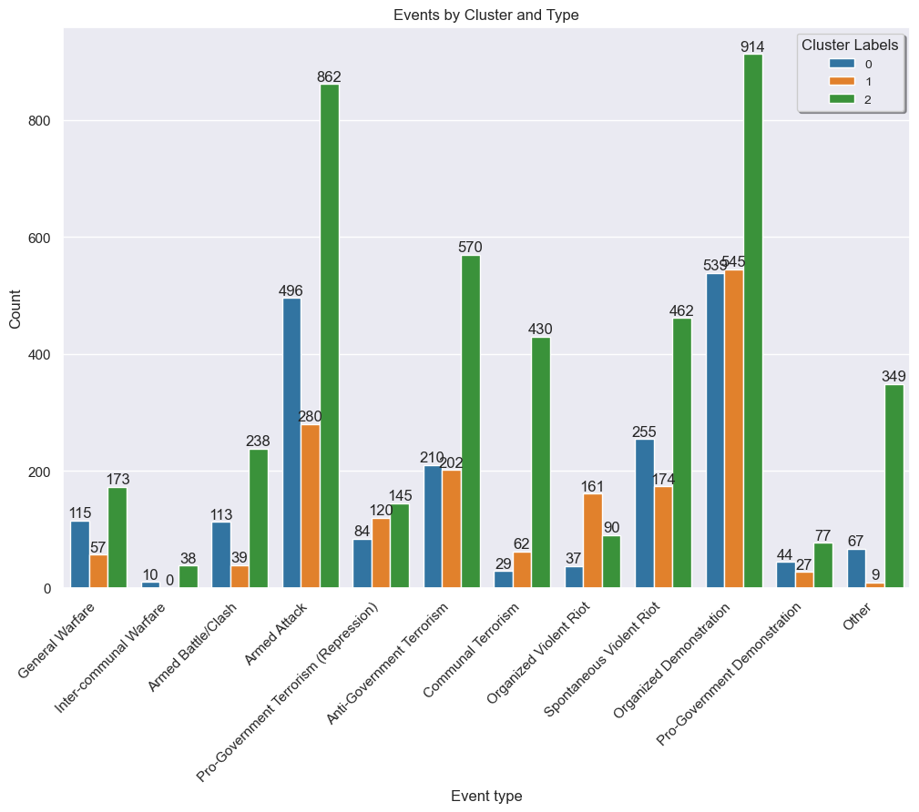

```python
# Set font scale and figure size
sns.set(font_scale=1)
plt.figure(figsize=(12,8))

# Define dictionary for region codes and event types
event_ticks = {1: 'General Warfare', 2: 'Inter-communal Warfare', 3: 'Armed Battle/Clash', 4: 'Armed Attack',
               5: 'Pro-Government Terrorism (Repression)', 6: 'Anti-Government Terrorism', 7: 'Communal Terrorism',
               8: 'Organized Violent Riot', 9: 'Spontaneous Violent Riot', 10: 'Organized Demonstration',
               11: 'Pro-Government Demonstration', 12: 'Other'}

# Create countplot
ax = sns.countplot(x='PTYPE', hue='CLUSTER_LABEL', data=df, palette='tab10')

# Set labels and title
plt.xlabel('Event type')
plt.xticks(range(12), [event_ticks[i] for i in range(1,13)], rotation=45, ha='right')
plt.ylabel('Count')
plt.title('Events by Cluster and Type')

# Set legend
ax.legend(title='Cluster Labels', title_fontsize='medium', fontsize='small', frameon=True, fancybox=True, shadow=True)

# Add annotations for count values
for p in ax.patches:
    ax.annotate(str(int(p.get_height())), (p.get_x() + p.get_width() / 2, p.get_height() + 5), ha='center')

# Show the plot
plt.show()
```

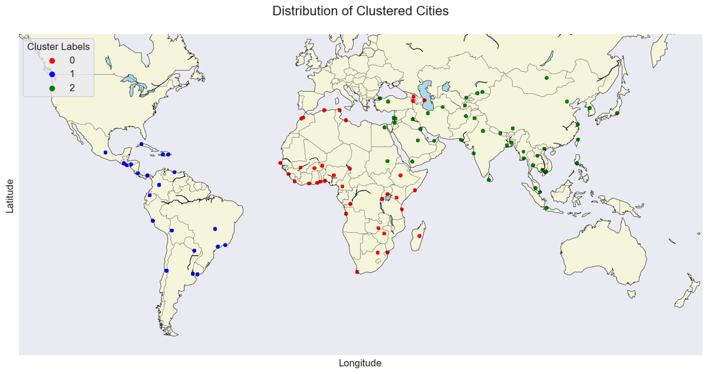

```python
# create figure object and set fig size
plt.figure(1, figsize=(15,8))

# set up basemap
m = Basemap(projection='merc', llcrnrlat=-60, urcrnrlat=60, llcrnrlon=-140, urcrnrlon=180, resolution='c')
# m.drawmapboundary(fill_color='#6495ED')
m.drawcoastlines(linewidth=0.5)
m.drawcountries(linewidth=0.3)
m.fillcontinents(color='beige', lake_color='lightblue')

# set colour mapping
color_dict = {0: "red", 1: "blue",2: "green"}
region_dict = {0: "Asia", 1: "Latin Americ", 2: "Middle East & North Africa", 3: "Sub-Saharan Afric"}

# mapping scatter plot with colours based on the CLUSTER_LABEL field of the data
x, y = m(df['LONG'].values, df['LAT'].values)
plt.scatter(x, y, c=df['CLUSTER_LABEL'].map(color_dict), s=10)

# add legend
for clusterLabel, color in color_dict.items():
    plt.scatter([], [], c=color, label=clusterLabel)
plt.legend(title='Cluster Labels', loc='upper left', fontsize=12)

# add labels and title
plt.xlabel("Longitude")
plt.ylabel("Latitude")
plt.title("Distribution of Clustered Cities\n", fontsize=16)

plt.show()
```

We found some clear patterns as followed:

## 4 Conclusion

This report explores the occurrence and patterns of political violence in urban areas across the developing world over the past 55 years. The research project used time series analysis to learn the number of incidents per year in each country or region and to attempt to predict the number of social disorder incidents in these regions in the future. The Urban Social Disorder (USD) event dataset 2.0 from Kaggle that provides information on disorder events in 103 cities across 89 countries in the developing world for the past 55 years (1960-2014) was analyzed.

The key findings of this research project are the identification of trends, patterns and the exploration of the potential for predicting the likelihood of its occurrence. The project also identified the government as the most popular target of social disorder events. The clustering analysis of cities was performed to reflect the similarities and differences between them, which may be crucial for some problems. It also suggests that the original data might have made more sense if the data had been divided into three regions. The time series analysis of the data provided insight into the spatial and temporal distribution patterns of social disorder events in these regions over the years.

One of the strengths of this research project is that it used a large dataset that covered a long time period and a wide range of locations although some of the data contained unknown values. The dropping of some data could result in a reduced sample size, which may be avoided by better methods. In the future, this research project could be expanded by incorporating more data sources and refining the data preprocessing and time series analysis techniques. Additionally, exploring the underlying causes of political violence in urban areas could provide more insight into how to prevent and mitigate its occurrence. Overall, this research project provided valuable insights into political violence in urban areas and has the potential to inform policies and interventions to reduce the incidence of such violence.

```python
# Word count for this file

import re
from nbformat import read

def count_words(file_path):
    # open file and read in contents
    with open(file_path, 'r', encoding='utf-8') as f:
        nb = read(f, as_version=4)

    # get words in markdown cells
    words = []
    for cell in nb.cells:
        if cell.cell_type == 'markdown':
            content = cell.source
            words_in_cell = re.findall(r'\b\w+\b', content)
            words.extend(words_in_cell)

    # words count
    word_count = len(words)

    # return the result
    return word_count

if __name__ == '__main__':
    file_path = 'URBAN5123_2749676J.ipynb'
    word_count = count_words(file_path)
    print(f'The file "{file_path}" contains {word_count} words in markdown cells.')
```

```
The file "URBAN5123_2749676J.ipynb" contains 2589 words in markdown cells.
```

## Reference list

Empirical Study of Event Data from Asian and Sub-Saharan African Cities. International Interactions, 38(4), pp.512–528. doi:https://doi.org/10.1080/03050629.2012.697427.